# Reproducible Research: Peer Assessment 1

Updates as of 18:17, Tue, Feb 03 (2015):

1. Fixed a few typos and minor grammar mistakes.
2. Rename the data.frame object ave3 as aves to distinguish from the two numeric vectors ave & ave2.

## Loading and preprocessing the data

- Load the data. You can download repdata-data-activity.zip from the link [here](https://d396qusza40orc.cloudfront.net/repdata%2Fdata%2Factivity.zip).

```r
link <- "http://d396qusza40orc.cloudfront.net/repdata%2Fdata%2Factivity.zip"
zip <- "repdata-data-activity.zip"
if (!file.exists("activity.csv")) {
        if (!file.exists(zip)) {
                download.file(url = link, destfile = zip)
                unzip(zip)
        } else {
                unzip(zip)
        }
}
```

- Load the data and process the data into a data frame.

```r
cols <- c("numeric", "POSIXct", "numeric")
dat <- read.csv("activity.csv", na.strings = c("NA", ""), colClasses = cols)
```

## What is the mean total number of steps taken per day?

- Calculate the total number of steps taken each day.

```r
sums <- aggregate(steps ~ date, data = dat, sum, na.rm = TRUE)
```

- Make a histogram of the total steps taken each day.

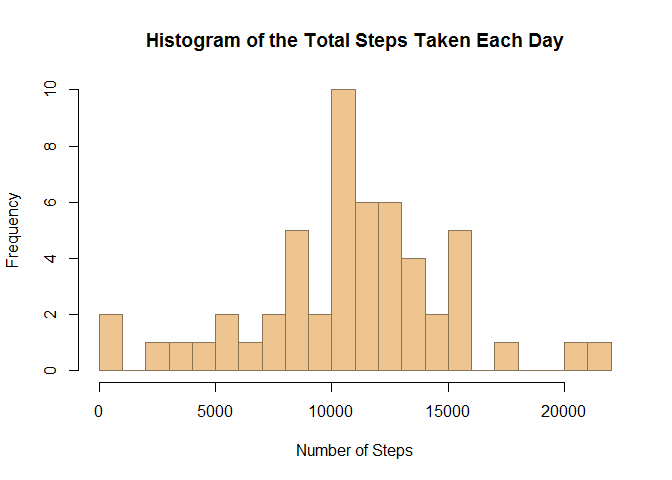

```r
library(datasets)
hist(sums$steps, col = "burlywood2", border = "burlywood4", breaks = 20,
     main = "Histogram of the Total Steps Taken Each Day",
     xlab = "Number of Steps")
```

- Calculate and report the mean of “the total steps taken per day”.

```r
ave <- mean(sums$steps, na.rm = TRUE)
print(ave)
```

```
## [1] 10766.19
```

The mean of the total steps is 10766.19 steps per day.

- Calculate and report the median of “the total steps taken per day”.

```r
med <- median(sums$steps, na.rm = TRUE)
print(med)
```

```
## [1] 10765
```

The median of the total steps is 10765 steps per day.

## What is the average daily activity pattern?

- Calculate the mean steps in each 5-minute interval averaged across all days.

```r
daily <- aggregate(steps ~ interval, data = dat, mean, na.rm = TRUE)
```

- Convert intervals to proper time format. (1970-01-01 is chosen for convenience in later calculations only)

```r
hr <- daily$interval %/% 100
min <- daily$interval %% 100
daily$interval <- as.POSIXct(paste("1970-01-01", hr, min),
                             format = "%Y-%m-%d %H %M")
```

- Make a time series plot of the 5-minute interval (x-axis) and the mean steps taken, averaged across all days (y-axis).

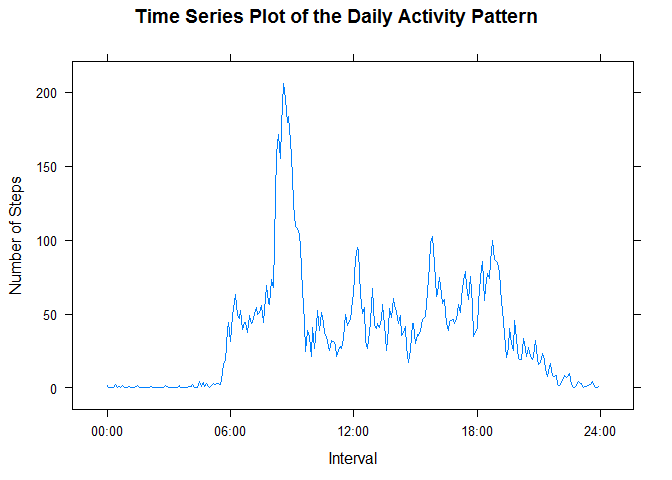

```r
locs <- c("1970-01-01 00:00:00", "1970-01-01 06:00:00", "1970-01-01 12:00:00",
              "1970-01-01 18:00:00", "1970-01-02 00:00:00")
ticklocs <- as.POSIXct(locs, format = "%Y-%m-%d %H:%M:%S")
ticknames <- c("00:00", "06:00", "12:00", "18:00", "24:00")
library(lattice)
xyplot(steps ~ interval, data = daily, type = "l", xlab = "Interval",
       ylab = "Number of Steps",
       main = "Time Series Plot of the Daily Activity Pattern",
       scales = list(x = list(at = ticklocs, labels = ticknames)))
```

- Find the 5-minute interval that, on average across all the days in the dataset, contains the maximum number of steps.

```r
MAXstp <- max(daily$steps, na.rm = TRUE)
MAXint <- daily[which(daily[,"steps"] == MAXstp), "interval"]
substr(MAXint, 12, 16)
```

```
## [1] "08:35"
```

The 5-minute interval starting at 08:35 on average across all the days, contains the maximum number of steps.

## Imputing missing values

- Calculate and report the total number of rows with missing values.

```r
NArows <- sum(!complete.cases(dat))
print(NArows)
```

```
## [1] 2304
```

The total number of rows with missing values is 2304.

- Create an updated dataset with all NAs filled in. (Fill in each missing value with the mean for that 5-minute interval)

```r
dat2 <- dat
for (i in 1:nrow(dat2)) {
        if (is.na(dat2$steps[i])) {
                if (i%%288 == 0) {
                        dat2$steps[i] <- daily$steps[288]
                } else {
                        dat2$steps[i] <- daily$steps[i%%288]
                }
        }
}
```

- Calculate the new total number of steps taken each day.

```r
sums2 <- aggregate(steps ~ date, data = dat2, sum)
```

- Make a new histogram of the total steps taken each day.

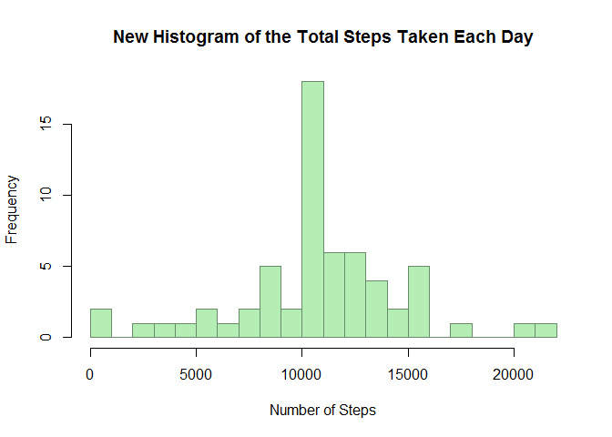

```r
library(datasets)
hist(sums2$steps, col = "darkseagreen2", border = "darkseagreen4", breaks = 20,
     main = "New Histogram of the Total Steps Taken Each Day",
     xlab = "Number of Steps")
```

- Calculate and report the new mean of “the total steps taken per day”.

```r
ave2 <- mean(sums2$steps)
print(ave2)
```

```
## [1] 10766.19
```

The new mean of the total steps is 10766.19.

- Calculate and report the new median of “the total steps taken per day”.

```r
med2 <- median(sums2$steps)
print(med2)
```

```
## [1] 10766.19
```

The new median of the total steps is 10766.19 steps per day.

- Do these values differ from the estimates from the first part of this report?

The mean (10766.19) remains the same as the estimate from the first part of this report, but the median (10766.19) differs slightly from the original estimate (10765).

- What is the impact of imputing missing data on the estimates of the total daily number of steps?

I think the purpose of trying to imput missing data is to make the dataset more complete. As shown in this report, the filling-in of missing values has changed the median of total steps taken per day, though the difference between the original median and the new median is small. In a much larger dataset, the presence of missing data could contribute to a conclusion that is more deviated from the reality, thus leading to mistakes in making decisions based on the dataset. Filling in these missing values with possible data would give us a more complete picture of the real situations.

## Are there differences in activity patterns between weekdays and weekends?

- Create a new factor variable in the dataset with two levels (weekday & weekend) indicating whether a given date is a weekday or weekend day.

```r
wkd <- weekdays(dat2$date)
dat2 <- cbind(dat2, wkd)
```

- Set the system locale to English (US) if it is not.

```r
if (!Sys.getlocale(category = "LC_TIME") == "English_United States.1252") {
        invisible(Sys.setlocale(category = "LC_TIME", "English"))
}
```

- Convert the interval in the new dataset to time format.

```r
dat2$interval <- daily$interval
```

- Create a new factor column in the new dataset indicating which day in a week the date on the same row is; then use it to sort the dataset based on whether the date is a weekday or a weekend day.

```r
wkd <- weekdays(dat2$date)
dat2 <- cbind(dat2, wkd)
dat3 <- split(dat2, dat2$wkd)
wkdy <- rbind(dat3[[1]], dat3[[2]], dat3[[5]], dat3[[6]], dat3[[7]])
wkdy$wkd <- "weekday"
wknd <- rbind(dat3[[3]], dat3[[4]])
wknd$wkd <- "weekend"
dat3 <- rbind(wkdy, wknd)
```

- Make a panel plot containing a time series plot of the 5-minute interval (x-axis) and the average number of steps taken, averaged across all weekday days or weekend days (y-axis).

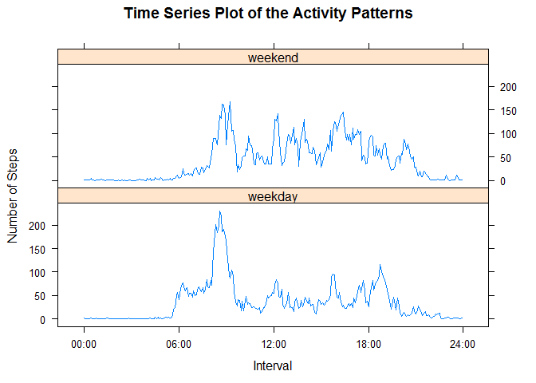

```r
aves <- aggregate(steps ~ interval + wkd, data = dat3, mean)
library(lattice)
xyplot(steps ~ interval | wkd, data = aves, type = "l", layout = c(1, 2),
       xlab = "Interval", ylab = "Number of Steps",
       main = "Time Series Plot of the Activity Patterns",
       scales = list(x = list(at = ticklocs, labels = ticknames)))
```

Based on the panel plot generated above, it is easy to tell that there are some differences in activity patterns between weekdays and weekends mainly during the hours from 6 am to midnight.